# Data Viz I

figures

graphics

plots

ggplot2

tidyverse

Author

Dr. Adrian Correndo

Published

January 30, 2026

**Description**

In this class, we will explore advanced visualization techniques using `ggplot2`. You’ll learn how to fine-tune plots by modifying shapes, lines, legends, and adding custom titles and annotations. We will continue working with the **`agridat::lasrosas.corn`** dataset.

[figure not shown]

# 1 Learning Objectives

By the end of this session, you will: 1. Customize plot aesthetics, including point shapes, line types, and colors. 2. Modify legends and axis labels for better readability. 3. Use annotations and text elements to highlight key data points. 4. Adjust themes and layouts for professional presentation.

**Required Packages**

Install the necessary packages for this class:

```r
library(pacman)
p_load("dplyr") # data wrangling
p_load("ggplot2", "agridat", "patchwork", "ggtext") # plotting
p_load("gganimate", "magick", "gifski") # animations
```

# 2 Datasets: Las Rosas Corn Data

We’ll use the **`agridat::lasrosas.corn`** dataset, focusing on yield, nitro levels, years, and spatial data.

```r
corn_data <- agridat::lasrosas.corn %>%
  mutate(Year = as.factor(year))

glimpse(corn_data)
```

```
Rows: 3,443
Columns: 10
$ year  <int> 1999, 1999, 1999, 1999, 1999, 1999, 1999, 1999, 1999, 1999, 1999…
$ lat   <dbl> -33.05113, -33.05115, -33.05116, -33.05117, -33.05118, -33.05120…
$ long  <dbl> -63.84886, -63.84879, -63.84872, -63.84865, -63.84858, -63.84851…
$ yield <dbl> 72.14, 73.79, 77.25, 76.35, 75.55, 70.24, 76.17, 69.17, 69.77, 6…
$ nitro <dbl> 131.5, 131.5, 131.5, 131.5, 131.5, 131.5, 131.5, 131.5, 131.5, 1…
$ topo  <fct> W, W, W, W, W, W, W, W, W, W, W, W, W, W, W, W, W, W, W, W, W, W…
$ bv    <dbl> 162.60, 170.49, 168.39, 176.68, 171.46, 170.56, 172.94, 171.86, …
$ rep   <fct> R1, R1, R1, R1, R1, R1, R1, R1, R1, R1, R1, R1, R1, R1, R1, R1, …
$ nf    <fct> N5, N5, N5, N5, N5, N5, N5, N5, N5, N5, N5, N5, N5, N5, N5, N5, …
$ Year  <fct> 1999, 1999, 1999, 1999, 1999, 1999, 1999, 1999, 1999, 1999, 1999…
```

```r
nass_soybean <- agridat::nass.soybean %>%
  mutate(Year = as.factor(year))

select_states <- c("Kansas", "Iowa", "Illinois", "Missouri")

glimpse(nass_soybean)
```

```
Rows: 2,528
Columns: 5
$ year  <int> 1924, 1924, 1924, 1924, 1924, 1924, 1924, 1924, 1924, 1924, 1924…
$ state <fct> Alabama, Arkansas, Delaware, Georgia, Illinois, Indiana, Iowa, K…
$ acres <dbl> 3000, 3000, 12000, 10000, 115000, 66000, 10000, 2000, 9000, 8000…
$ yield <dbl> 6.5, 6.5, 11.0, 5.5, 12.0, 9.9, 12.0, 11.0, 9.5, 8.0, 11.8, 13.0…
$ Year  <fct> 1924, 1924, 1924, 1924, 1924, 1924, 1924, 1924, 1924, 1924, 1924…
```

# 3 1. Customizing ggplot2 Visualizations

## 3.1 Define custom palettes

```r
my_colors <- c("#1e6091", "#f9c74f", "#9b2226",  "#599999",  "#8e5572")
years_colors <- c("1999" = "#1e6091", "2001" = "#9b2226")
```

## 3.2 Histogram with Adjusted Transparency and Custom Bins

### 3.2.1 i. First layers

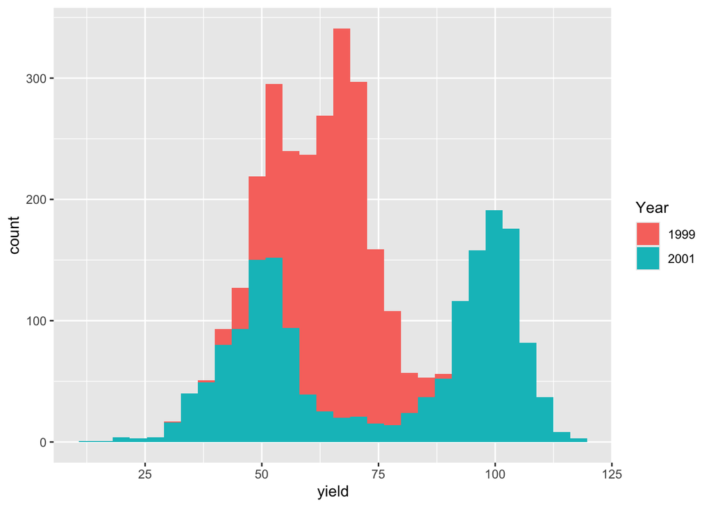

```r
corn_data %>%
  ggplot(aes(x=yield))+ # create the canvas with x axis defined
  geom_histogram(aes(fill = Year)) # add histogram layer with Year colors
```

### 3.2.2 ii. Add more layers and labels

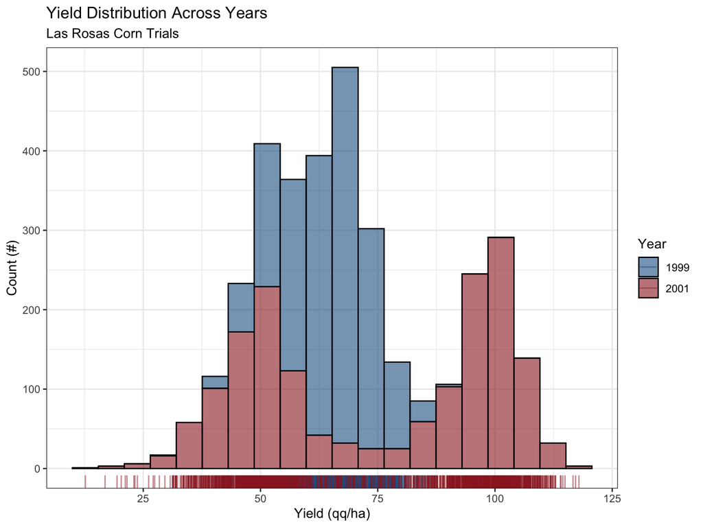

```r
# Histogram
histo_01 <-
corn_data %>%
ggplot(aes(x = yield)) +
  # Layers
  geom_histogram(aes(fill = Year), bins = 20, alpha = 0.6, color = "black") +
  geom_rug(aes(color = Year), alpha = 0.5)+
  # Labels
  labs(title = "Yield Distribution Across Years",
       subtitle = "Las Rosas Corn Trials",
       x = "Yield (qq/ha)",
       y = "Count (#)") +
  # Scales
  scale_fill_manual(values = years_colors)+
  scale_color_manual(values = years_colors)+
  theme_bw()

histo_01
```

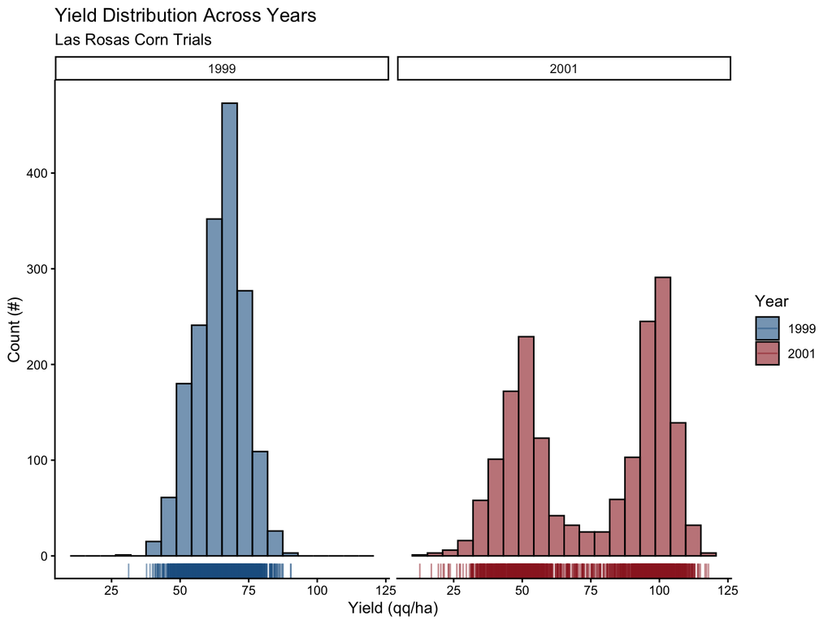

```r
# Faceting by Year
histo_02 <-
  corn_data %>%
ggplot(aes(x = yield)) +
  # Layers
  geom_histogram(aes(fill = Year), bins = 20, alpha = 0.6, color = "black") +
  geom_rug(aes(color = Year), alpha = 0.5)+
  # Labels
  labs(title = "Yield Distribution Across Years",
       subtitle = "Las Rosas Corn Trials",
       x = "Yield (qq/ha)",
       y = "Count (#)") +
  # Scales
  scale_fill_manual(values = years_colors)+
  scale_color_manual(values = years_colors)+
  facet_wrap(~Year)+
  theme_classic()

histo_02
```

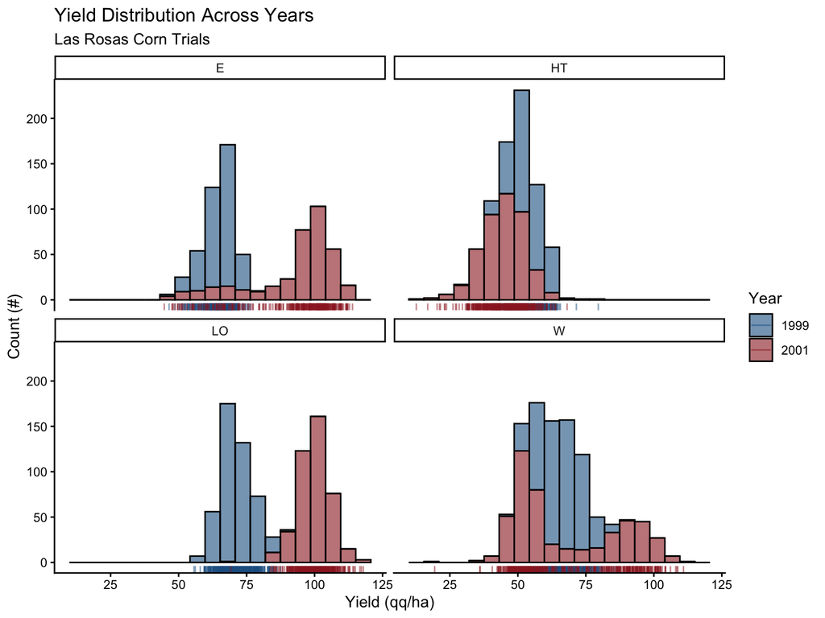

```r
# Faceting by Year
histo_03 <-
  corn_data %>%
ggplot(aes(x = yield)) +
  # Layers
  geom_histogram(aes(fill = Year), bins = 20, alpha = 0.6, color = "black") +
  geom_rug(aes(color = Year), alpha = 0.5)+
  # Labels
  labs(title = "Yield Distribution Across Years",
       subtitle = "Las Rosas Corn Trials",
       x = "Yield (qq/ha)",
       y = "Count (#)") +
  # Scales
  scale_fill_manual(values = years_colors)+
  scale_color_manual(values = years_colors)+
  facet_wrap(~topo)+
  theme_classic()

histo_03
```

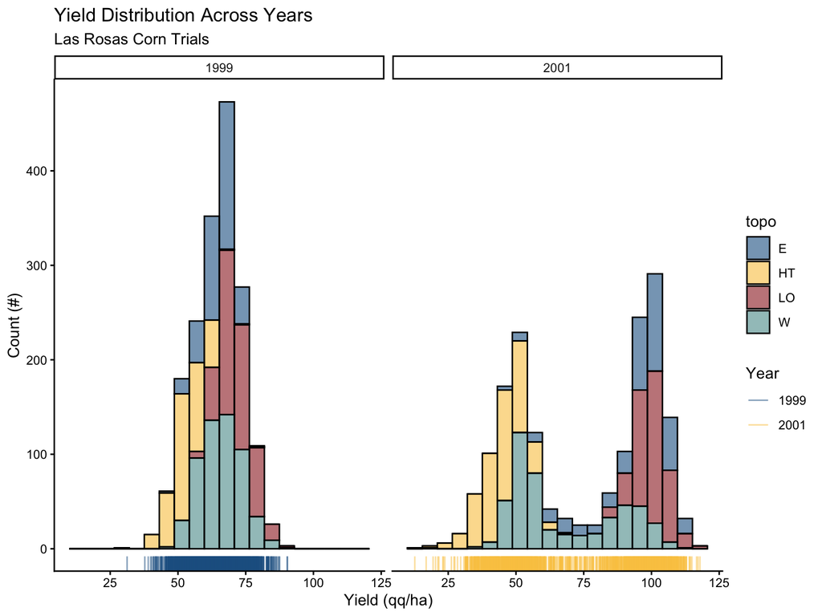

```r
# Faceting by Year
histo_04 <-
  corn_data %>%
ggplot(aes(x = yield)) +
  # Layers
  geom_histogram(aes(fill = topo), bins = 20, alpha = 0.6, color = "black") +
  geom_rug(aes(color = Year), alpha = 0.5)+
  # Labels
  labs(title = "Yield Distribution Across Years",
       subtitle = "Las Rosas Corn Trials",
       x = "Yield (qq/ha)",
       y = "Count (#)") +
  # Scales
  scale_fill_manual(values = my_colors)+
  scale_color_manual(values = my_colors)+
  facet_wrap(~Year)+
  theme_classic()

histo_04
```

### 3.2.3 Density plot

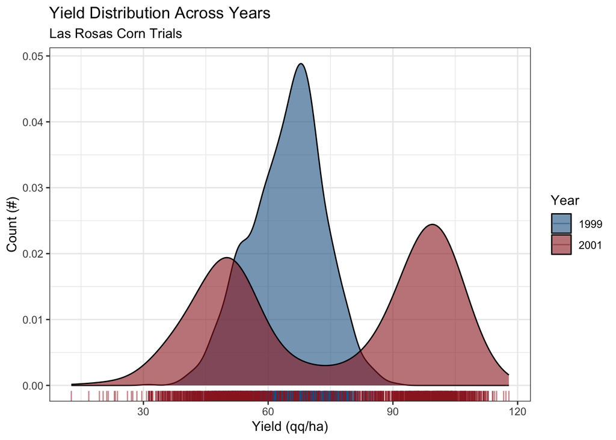

```r
corn_data %>%
ggplot(aes(x = yield)) +
  # Layers
  geom_density(aes(fill = Year), bins = 20, alpha = 0.6, color = "black") +
  geom_rug(aes(color = Year), alpha = 0.5)+
  # Labels
  labs(title = "Yield Distribution Across Years",
       subtitle = "Las Rosas Corn Trials",
       x = "Yield (qq/ha)",
       y = "Count (#)") +
  # Scales
  scale_fill_manual(values = years_colors)+
  scale_color_manual(values = years_colors)+
  theme_bw()
```

## 3.3 Column/Bar plot

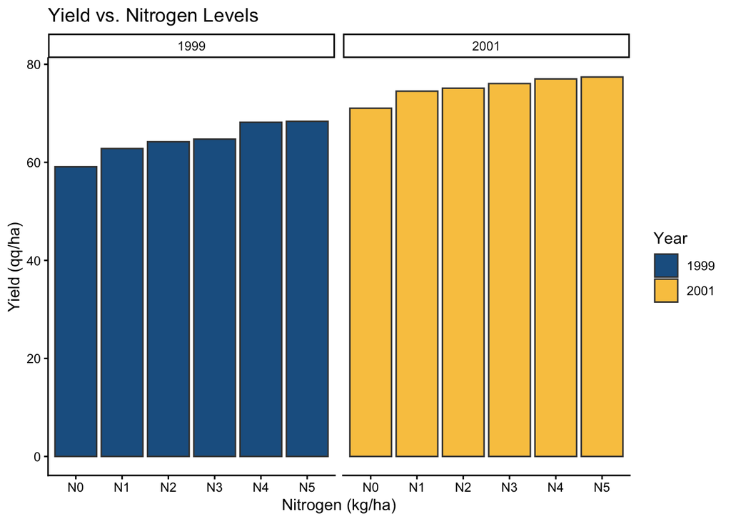

```r
# Prepare summarized data frame
aggregated_corn <-
  corn_data %>%
  group_by(Year, year, nitro, nf) %>%
  summarize(yield_mean = mean(yield),
            sd_yield = sd(yield))
# Column plot
colplot_01 <-
  aggregated_corn %>%
ggplot() +
  geom_col(aes(x = nf, y = yield_mean, fill = Year),
           color = "grey25") + # Triangle shape
  scale_fill_manual(values = my_colors)+
  labs(title = "Yield vs. Nitrogen Levels", x = "Nitrogen (kg/ha)", y = "Yield (qq/ha)") +
  facet_wrap(~Year)+
  theme_classic()

colplot_01
```

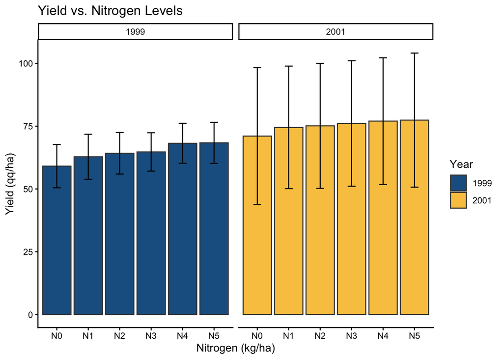

```r
# Add SD bars
colplot_02 <-
colplot_01 +
  geom_errorbar(data = aggregated_corn,
                aes(ymin = yield_mean - sd_yield,
                    ymax = yield_mean + sd_yield,
                    x = nf),
                width = .25)


colplot_02
```

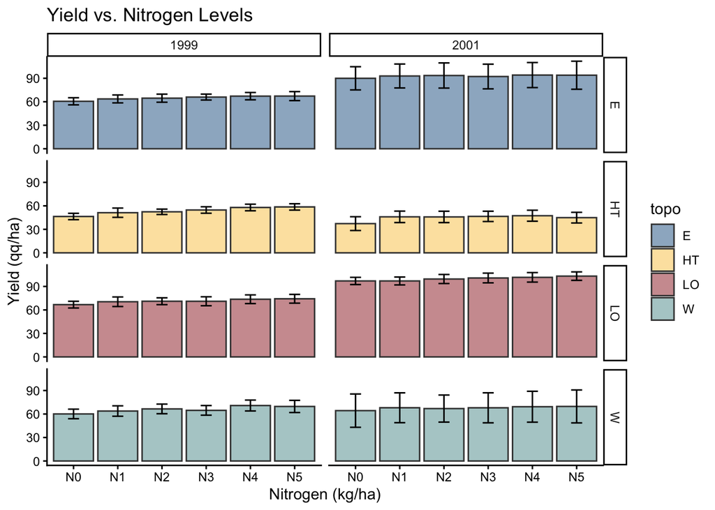

```r
# facet by topography
aggregated_topo <- corn_data %>%
  group_by(Year, year, nitro, nf, topo) %>%
  summarize(yield_mean = mean(yield),
            sd_yield = sd(yield))
# dacet by topography and Year
colplot_03 <-
aggregated_topo %>%
ggplot() +
  geom_col(aes(x = nf, y = yield_mean, fill = topo),
           color = "grey25", alpha = 0.5) +
  geom_errorbar(aes(ymin = yield_mean - sd_yield,
                    ymax = yield_mean + sd_yield, x = nf),
                width = .25)+
  labs(title = "Yield vs. Nitrogen Levels", x = "Nitrogen (kg/ha)", y = "Yield (qq/ha)") +
  facet_grid(topo~Year)+
  scale_fill_manual(values = my_colors)+
  theme_classic()

colplot_03
```

## 3.4 Scatter Plot with Custom Shapes and Line Types

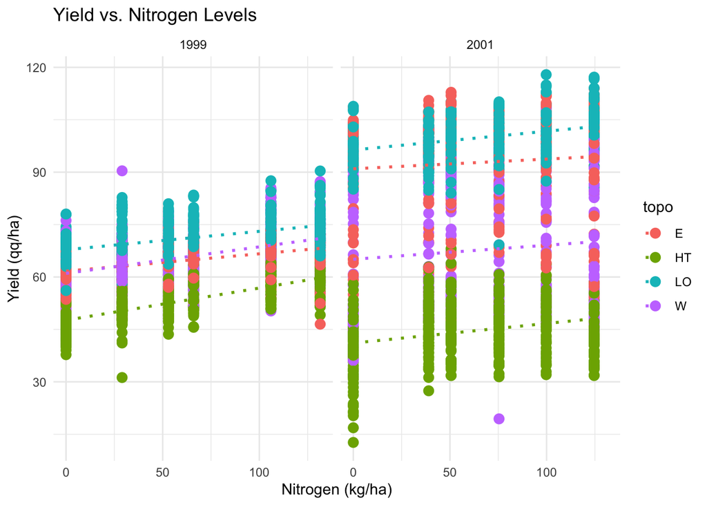

```r
# By year
scatter_01 <- corn_data %>%
ggplot(aes(x = nitro, y = yield, color = factor(year))) +
  geom_point(size = 3, shape = 17) + # Triangle shape
  geom_smooth(method = "lm", se = FALSE, linetype = "dashed") +
  labs(title = "Yield vs. Nitrogen Levels", x = "Nitrogen (kg/ha)", y = "Yield (qq/ha)") +
  theme_minimal()

# by topography
scatter_02 <- corn_data %>%
ggplot(aes(x = nitro, y = yield, color = topo)) +
  geom_point(size = 3, shape = 19) + # Circle shape
  geom_smooth(method = "lm", se = FALSE, linetype = "dotted") +
  labs(title = "Yield vs. Nitrogen Levels", x = "Nitrogen (kg/ha)", y = "Yield (qq/ha)") +
  facet_wrap(~Year)+
  theme_minimal()

scatter_02
```

## 3.5 BoxPlot with Custom Shapes and Line Types

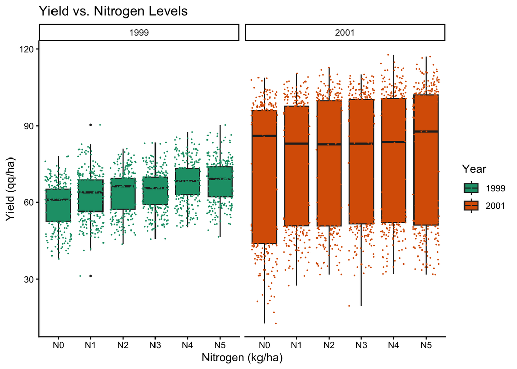

```r
corn_data %>%
ggplot(aes(x = nf, y = yield)) +
  geom_boxplot(aes(fill = Year), color = "grey15", size = 0.5) +
  geom_jitter(aes(x = nf, y = yield, color=Year), size = 0.1)+
  scale_fill_brewer(palette=2, type = "qual")+
  scale_color_brewer(palette=2, type = "qual")+
  labs(title = "Yield vs. Nitrogen Levels",
       x = "Nitrogen (kg/ha)", y = "Yield (qq/ha)") +
  facet_wrap(~Year)+
  theme_classic()
```

# 4 2. Axis & Titles

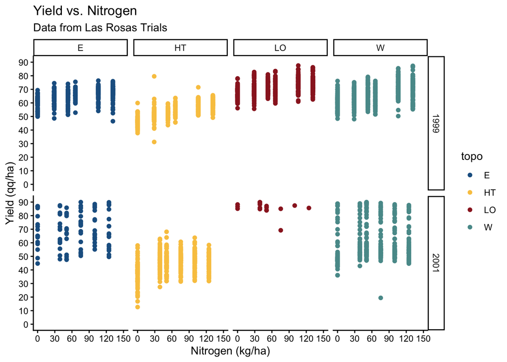

```r
scatter_plot <-
corn_data %>%
ggplot(aes(x = nitro, y = yield, color = topo)) +
  geom_point()+
  # Add labels
  labs(title = "Yield vs. Nitrogen",
       subtitle = "Data from Las Rosas Trials",
       x = "Nitrogen (kg/ha)",
       y = "Yield (qq/ha)") +
  # Add manual color scale
  scale_color_manual(values = my_colors)+
  # Modify scale of x-axis
  scale_x_continuous(limits = c(0,150), breaks = seq(0,150, by=30))+
  scale_y_continuous(limits = c(0,90), breaks = seq(0,90, by=10))+
  facet_grid(Year~topo)+
  theme_classic()

scatter_plot
```

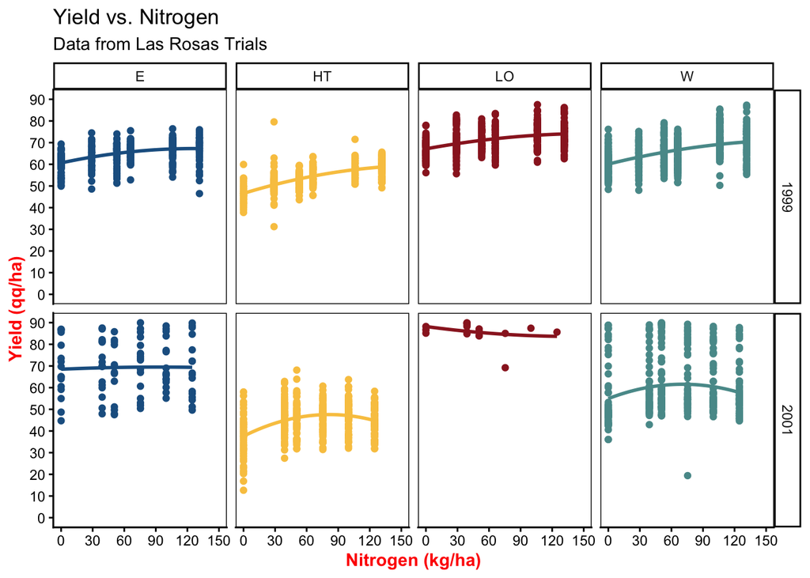

```r
# Update
scatter_plot +
  # Add regression line
  geom_smooth(method = "lm", formula = y ~ x + I(x^2), se = FALSE)+
  theme(legend.position = "none", # Remove legend
        # Add panel border
        panel.border = element_rect(linetype = "solid", fill = NA),
        # Edit axis title text
        axis.title = element_text(face = "bold", color = "red"))
```

# 5 3. Annotating text

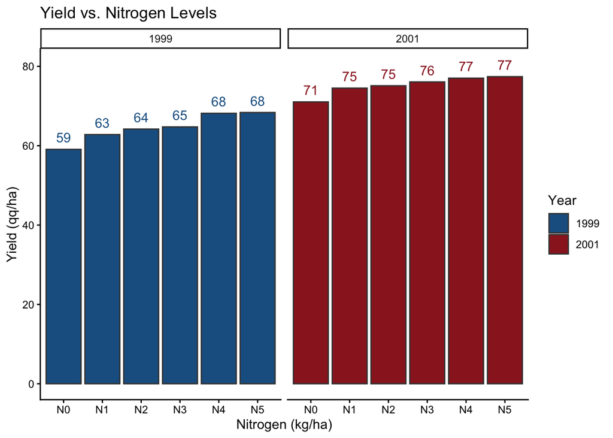

```r
colplot_01 +
  scale_fill_manual(values = years_colors)+
  geom_text(aes(label = round(yield_mean,0), x = nf, y = yield_mean + 3,
                color = Year))+
  scale_color_manual(values=years_colors)
```

# 6 4. Adjusting Themes for Presentation

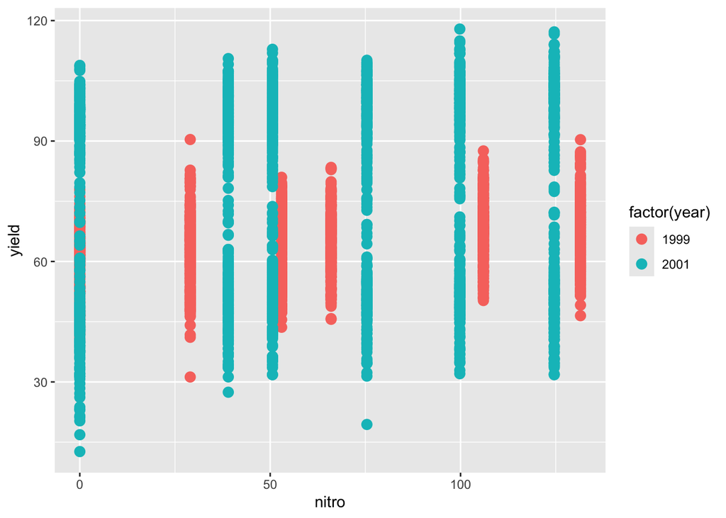

```r
base_plot <- ggplot(corn_data, aes(x = nitro, y = yield, color = factor(year))) +
  geom_point(size = 3)
base_plot
```

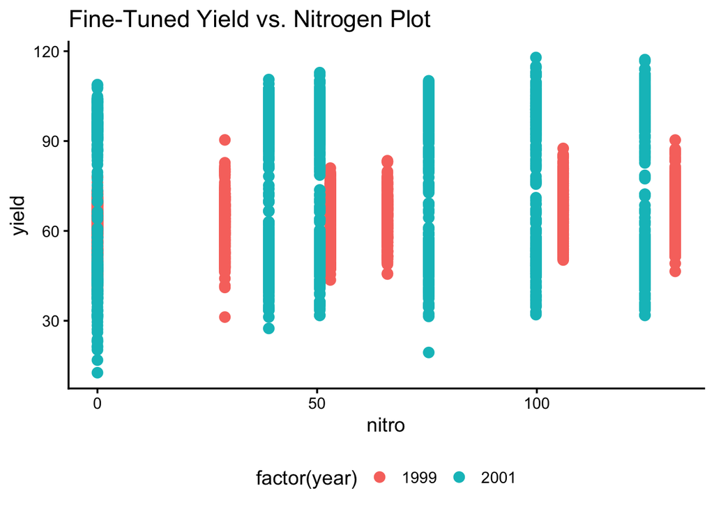

```r
base_plot +
  labs(title = "Fine-Tuned Yield vs. Nitrogen Plot") +
  theme_classic(base_size = 14) + # Larger base font
  theme(legend.position = "bottom")
```

# 7 5. Combining Multiple Plots with Custom Layouts

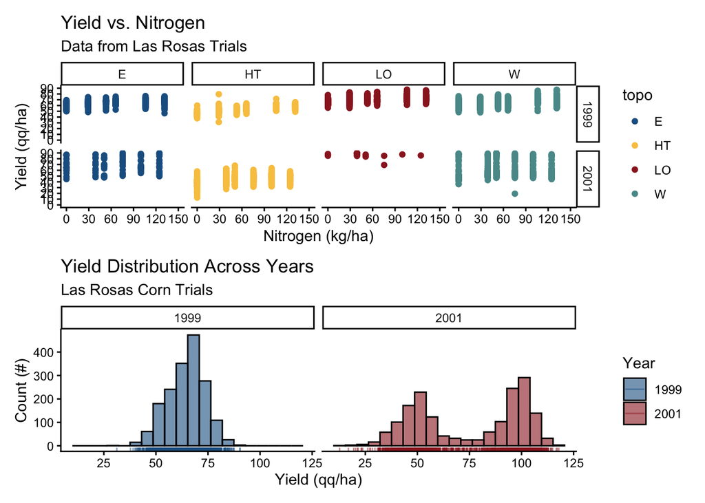

```r
p1 <- scatter_plot

p2 <- histo_02

# Combine using patchwork
p1 + p2 + plot_layout(ncol = 1)
```

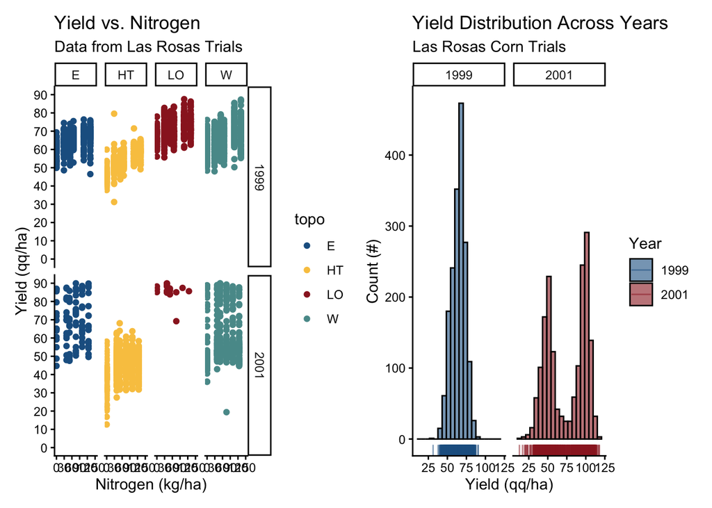

```r
p1 + p2 + plot_layout(ncol = 2)
```

# 8 6. Animated plots

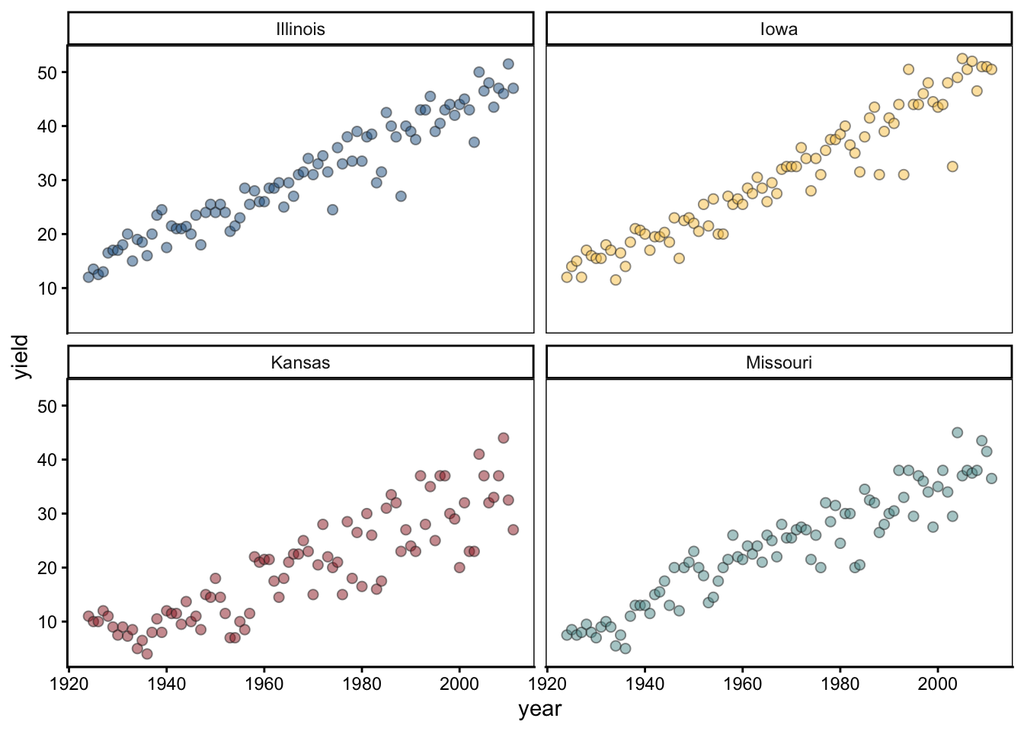

```r
static_plot <-
  nass_soybean %>%
  dplyr::filter(state %in% select_states) %>%
  ggplot(aes(x = year, y = yield)) +
  geom_point(aes(fill = state,
                 group = seq_along(year)),
             color = "grey15", shape = 21, size = 2, alpha = 0.5)+
  scale_fill_manual(values=my_colors)+
  #scale_color_manual(values=my_colors)+
  facet_wrap(~state)+
  theme_classic()+
  # Add panel border
  theme(legend.position = "none",
        panel.border = element_rect(linetype = "solid", fill = NA))

static_plot
```

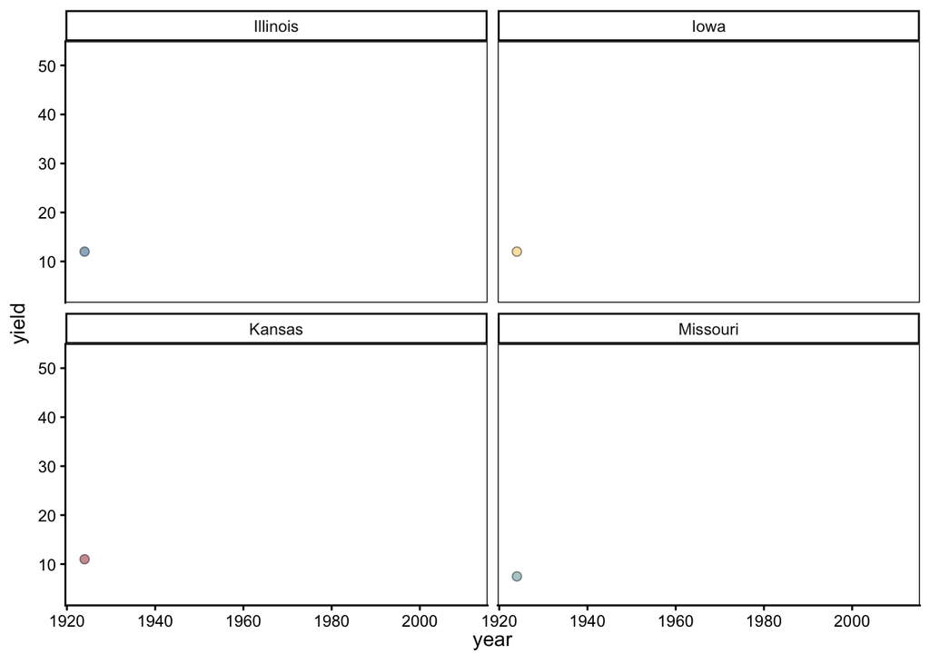

```r
animated_plot <-
  static_plot+
  transition_reveal(year)

animated_plot
```

```r
# Render the animation
# gganimate::animate(animated_plot, fps = 20, duration = 4,
#                     width = 400, height = 300,
#          renderer = gifski_renderer())

# Save
# anim_save(filename = "animated_plot.gif", animation = last_animation())
```

# 9 Conclusion

This tutorial provides various ggplot2 customization techniques relevant to agricultural research. Experiment with different styling options to enhance the clarity and impact of your visualizations!

# 10 Additional Resources for Data Visualization

Here are some excellent resources to deepen your understanding of data visualization:

1. **[ggplot2 Documentation](https://ggplot2.tidyverse.org/)** – The official documentation for ggplot2 with comprehensive guides and examples.
2. **[R Graphics Cookbook](https://r-graphics.org/)** – A collection of practical recipes for creating a wide variety of graphics with ggplot2.
3. **[The Grammar of Graphics](https://www.springer.com/gp/book/9780387245447)** by Leland Wilkinson – The foundational theory behind ggplot2.
4. **[Data Visualization: A Practical Introduction](https://socviz.co/)** by Kieran Healy – An excellent resource for both beginners and advanced users.
5. **[Tidyverse Tutorials](https://www.tidyverse.org/learn/)** – Tutorials on ggplot2 and related packages in the Tidyverse ecosystem.
6. **[R Graph Gallery](https://r-graph-gallery.com/)** – A rich gallery of ggplot2 visualizations for inspiration and code snippets.

Explore these resources to expand your visualization skills and stay updated with best practices in data presentation!